# Comparing Management Scenario Model Runs

Ballard Locks Case Study

October 23, 2024

## Purpose

The purpose of this document is to create figures that enable direct comparison between management scenario model runs, explanation of differences, and interpretation of what that means for the system. These four management scenarios are just preliminary options to help in the process of developing more realistic management scenarios for each case study.

## Description of the Management Scenarios

In the Ballard Locks case study we ran four preliminary scenarios:

#### Base Run

Simulates current dynamics in the Gauntlet.

#### Boat Harvest

Simulates amplified harvest by fishers during normal fishing seasons. Alters values for the steepness and efficiency parameters that describe the relationship between the number of fishers and the number of pinnipeds that are harvested.

#### Zone Exclusion

Simulates removals by managers to attempt to exclude all pinnipeds from the Gauntlet. Assumes that incidental take during the coho fishery is not also occurring simultaneously. Alters the process of removals from boat-based to a “zone” scenario that is governed by an efficiency which describes how many of the pinnipeds at that Gauntlet managers can effectively remove (despite aiming for 100% removal).

#### Haulout Reduction

Simulates removals or disturbance by managers to reduce overall pinnipeds in the source pool. Reduces the total number of pinnipeds by a reduction parameter. Incidental take during the Coho fishery occurs during this scenario.

## Salmon Response

The total daily salmon presence at the Gauntlet follows two main peaks for the Sockeye run and the Coho run. The zone management scenario causes the highest abundance of salmon at the Gauntlet, while the other scenarios result in lower abundance. The difference between management scenarios is much more pronounced during the later part of the year, during the Chinook and coho runs.

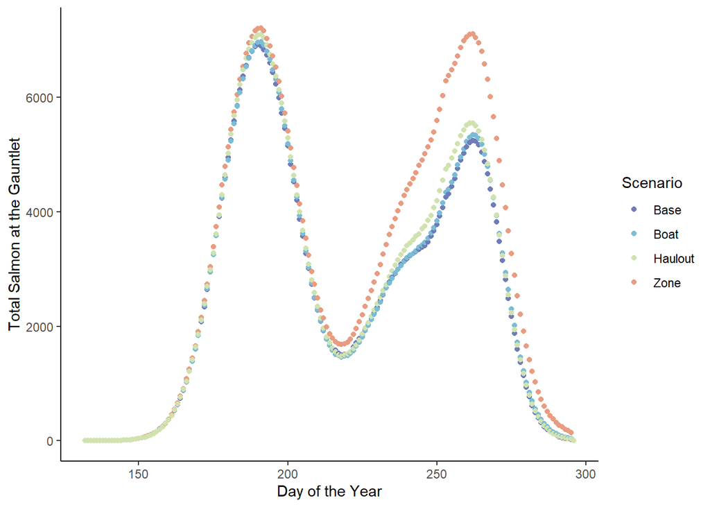

#### Escape

Escaped Salmon

|  | Sockeye | Chinook | Coho |
| --- | --- | --- | --- |
| Zone | 65566 | 2875 | 9833 |
| Haulout | 63510 | 1934 | 8808 |
| Boat | 62246 | 1774 | 8963 |
| Base | 61969 | 1750 | 8747 |

Overall, it appears that the zone exclusion management scenario could have a measurable positive impact on Sockeye abundance and survival beyond the Gauntlet. However, this result is highly dependent on the parameterization of this scenario, specifically the assumption that managers could feasibly remove 80% of seals from the Gauntlet daily during the entire duration of the salmon runs.

#### Predation

Predated by Pinnipeds

|  | Sockeye | Chinook | Coho |
| --- | --- | --- | --- |
| Zone | 3283 | 4701 | 2750 |
| Haulout | 5342 | 6582 | 4289 |
| Boat | 6607 | 6861 | 4045 |
| Base | 6885 | 6927 | 4376 |

[figure not shown]

#### Fishery Catch

In this model, fisheries catch are static rates that are enacted for the duration of the fishing season (which targets Coho but incidentally catches Chinook). Because of this approach, they are highly sensitive to increases in abundance and decreases in competition with predators. The zone management scenario produces the greatest increases in catch compared to all other scenarios for Chinook and coho.

Fishery Catch

|  | Sockeye | Chinook | Coho |
| --- | --- | --- | --- |
| Zone | 0 | 1583 | 4530 |
| Haulout | 0 | 759 | 4038 |
| Boat | 0 | 644 | 4119 |
| Base | 0 | 606 | 4012 |

## Pinniped Response

#### Harvest Summary

Parameters mentioned in parentheses are listed in the parameter table at the end of this document.

During the Coho fishery, we model the number of active fishers as a random draw from the range of 13-25 possible fishers (parameters: min_fishers, max_fishers). The fishery only operates above the Locks, so we assume that only 10% (parameter: availability) of harbor seals and 0 sea lions venture above the Locks.

In scenarios with incidental take only, we assume that fishers harvest 0.5% of the pinnipeds they encounter (parameter: accuracy), resulting in an incidental take rate of 5% (parameter: efficiency). In the boat-based scenario, we assume that fishers harvest 0.9% of the pinnipeds they encounter, resulting in an overall boat-based harvest of 9%.

When fisheries are not open, there is no fishing activity in the Gauntlet, and therefore no boat-based take or incidental pinniped take. In the zone management scenario, it is assumed that removals are occuring at high levels every day, which results in more total pinnipeds removed. The following plot shows the cumulative number of seals and sea lions that are removed from the Gauntlet over time under each management scenario. All takes associated with the haulout reduction strategy occur outside the Gauntlet and outside of the model time frame and therefore are not accounted for below.

Harvested Pinnipeds

|  | Pv | Zc | Ej |
| --- | --- | --- | --- |
| Zone | 62 | 2 | 0 |
| Boat | 15 | 0 | 0 |
| Base | 6 | 0 | 0 |
| Haulout | 1 | 0 | 0 |

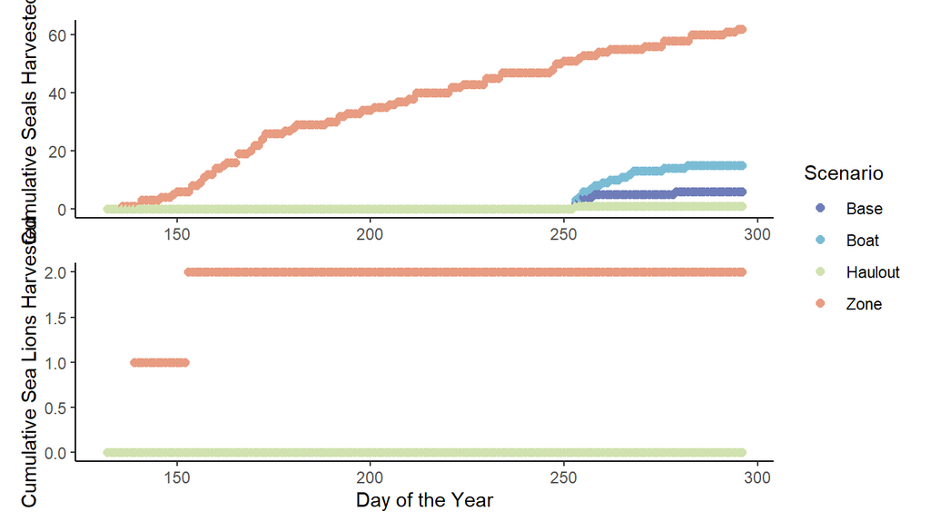

At the Locks, the zone management scenario clearly results in the largest number of removals, but requires a ton of effort to accomplish that. Boat-based harvest still removes a decent number of animals, but without access to the area below the Locks it is impossible to remove a large proportion of animals and as a result is not a huge improvement on the base run scenario.

#### Pinniped Activity

The following plots describe pinniped presence at the Gauntlet under all four scenarios for each pinniped species separately. You can see that the magnitude of presence differs greatly between scenarios. In the base scenario few removals are happening in the Gauntlet so pinniped presence closely tracks the timing and magnitude of each salmon run. In the boat-based harvest scenario, pinniped presence follows the Sockeye run, but cuts off sharply as soon as fishers become active in the Gauntlet. In the zone management scenario, pinniped presence is low throughout the model run due to the constant fear conditioning from daily removal activity. In the haulout reduction scenario, pinniped presence is reduced but still impacted by low-level incidental take during the fishery.

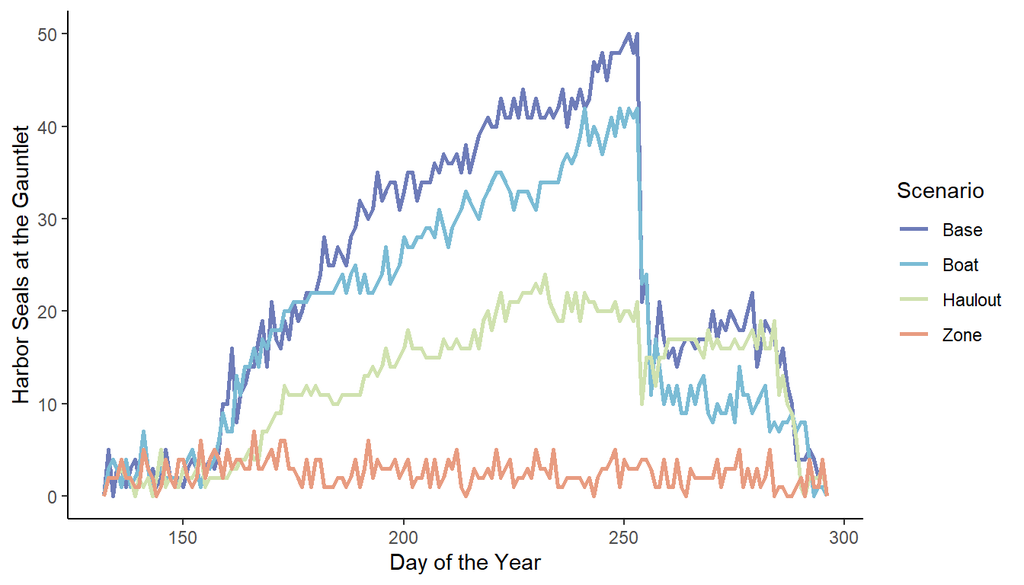

From this evidence, either the zone management or haulout reduction scenario would noticeably reduce harbor seal presence at the Locks.

There are very few sea lions in this model, so their presence is very noisy and there doesn’t seem to be clear differences between scenarios.

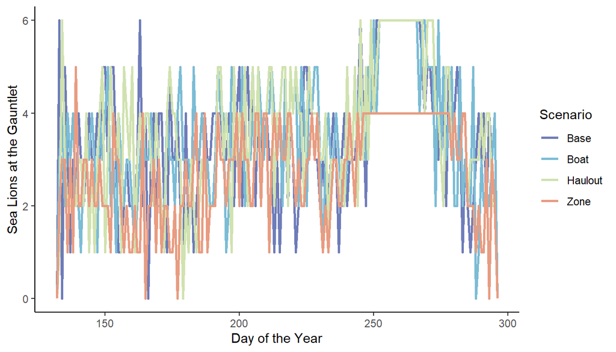

## Conclusion (for now)

Overall it looks like the zone exclusion management scenario would be the most effective at increasing salmon survival through the Gauntlet and decreasing predation by pinnipeds. However, this scenario assumes a high level of effort to remove large portions of the animals at the Gauntlet daily, which may not be feasible.

The haulout reduction strategy seems to have a smaller positive effect on Sockeye survival, but very little impact on Chinook or Coho. The boat-based harvest scenario is not very effective in this system because of the geographic limitations on where the fishery happens and how many pinnipeds are available to fishers above the Locks.

## Parameter Table

The following table summarizes the parameters that were altered to simulate the different management scenarios, or ones that are particularly relevant to specific scenarios.

Parameter Table

|  | Base | Boat | Zone | Haulout |
| --- | --- | --- | --- | --- |
| start_loop | 132 | 132 | 132 | 132 |
| end_loop | 296 | 296 | 296 | 296 |
| num_seals | 150 | 150 | 150 | 75 |
| prop_specialists | 0.1 | 0.1 | 0.1 | 0.1 |
| num_zc | 5 | 5 | 5 | 5 |
| num_ej | 1 | 1 | 1 | 1 |
| min_fishers | 13 | 13 | 13 | 13 |
| max_fishers | 25 | 25 | 25 | 25 |
| fishery_open | 253 | 253 | 253 | 253 |
| fishery_close | 321 | 321 | 321 | 321 |
| sockeye_residence | 3 | 3 | 3 | 3 |
| chinook_residence | 66 | 66 | 66 | 66 |
| coho_residence | 10 | 10 | 10 | 10 |
| zone_efficiency | NA | NA | 0.8 | NA |
| zone_steepness | NA | NA | 5 | NA |
| steepness_H | 20 | 5 | NA | 20 |
| availability | 0.1 | 0.1 | 0.1 | 0.1 |
| accuracy | 0.5 | 0.9 | NA | 0.5 |
| efficiency | 0.05 | 0.09 | NA | 0.05 |
| scenario | Boat | Boat | Zone | Boat |
| scenario_sealion | None | None | Zone | None |